# Trabajo_Personal_JavierML

Javier Martínez Lanciego

24/1/2022

# TRABAJO PERSONAL

Para la realización del trabajo, se hace uso de la dataset “nycflights13”. Para ello, primero se lleva a cabo la instalación del paquete.

## 1. Encuentra todos los vuelos que llegaron más de una hora tarde de lo previsto.

```r
library(tidyverse)
library(lubridate)
fly<- nycflights13::flights


tarde <- fly[which(fly$arr_delay>60),]

dim(tarde)
```

```
## [1] 27789    19
```

```r
print("Hay 27789 vuelos que llegaron mas de una hora tarde")
```

```
## [1] "Hay 27789 vuelos que llegaron mas de una hora tarde"
```

## 2. Encuentra todos los vuelos que volaron hacia San Francisco (aeropuertos SFO y OAK)

```r
ejer2<- fly[fly$dest == "SFO" | fly$dest == "OAK", ]
dim(ejer2)
```

```
## [1] 13643    19
```

```r
print("13643 vuelos volaron hacia San Francisco")
```

```
## [1] "13643 vuelos volaron hacia San Francisco"
```

## 3. Encuentra todos los vuelos operados por United American (UA) o por American Airlines (AA)

```r
ejer3<- fly[fly$carrier == "UA" | fly$carrier == "AA", ]
dim(ejer3)
```

```
## [1] 91394    19
```

```r
print("91394 fueron operados por United American o American Airlines")
```

```
## [1] "91394 fueron operados por United American o American Airlines"
```

## 4. Encuentra todos los vuelos que salieron los meses de primavera (Abril, Mayo y Junio)

```r
ejer4 <- fly[fly$month == 4 | fly$month == 5 | fly$month == 6, ]
dim(ejer4)
```

```
## [1] 85369    19
```

```r
print("85369 vuelos salieron en primavera")
```

```
## [1] "85369 vuelos salieron en primavera"
```

## 5. Encuentra todos los vuelos que llegaron más de una hora tarde pero salieron con menos de una hora de retraso.

```r
ejer5 <- fly[which(fly$arr_delay>60 & fly$dep_delay<60), ]
dim(ejer5)
```

```
## [1] 4956   19
```

```r
print("4956 vuelos llegaron mas de una hora tarde habiendo salido con menos de una hora de retraso")
```

```
## [1] "4956 vuelos llegaron mas de una hora tarde habiendo salido con menos de una hora de retraso"
```

## 6. Encuentra todos los vuelos que salieron con más de una hora de retraso pero consiguieron llegar con menos de 30 minutos de retraso (el avión aceleró en el aire)

```r
ejer6 <- fly[which(fly$dep_delay>60 & fly$arr_delay<30), ]
dim(ejer6)
```

```
## [1] 181  19
```

```r
print("En 181 ocasiones el avion salio mas de una hora tarde pero consiguio llegar con menos de 30 minutos de retraso")
```

```
## [1] "En 181 ocasiones el avion salio mas de una hora tarde pero consiguio llegar con menos de 30 minutos de retraso"
```

## 7. Encuentra todos los vuelos que salen entre medianoche y las 7 de la mañana (vuelos nocturnos).

```r
ejer7 <- fly[which(fly$hour>=0 & fly$hour<=7), ]
dim(ejer7)
```

```
## [1] 50726    19
```

```r
print("50726 vuelos se produjeron entre las medianoche y las 7 de la mañana")
```

```
## [1] "50726 vuelos se produjeron entre las medianoche y las 7 de la mañana"
```

## 8. ¿Cuántos vuelos tienen un valor desconocido de dep_time?

```r
ejer8 <- fly[is.na(fly$dep_time), ]
dim(ejer8)
```

```
## [1] 8255   19
```

```r
print("8255 vuelos tienen un valor desconocido de dep_time")
```

```
## [1] "8255 vuelos tienen un valor desconocido de dep_time"
```

## 9. ¿Qué variables del dataset contienen valores desconocidos?

```r
apply(X = is.na(fly), MARGIN = 2, FUN = sum)
```

```
##           year          month            day       dep_time sched_dep_time
##              0              0              0           8255              0
##      dep_delay       arr_time sched_arr_time      arr_delay        carrier
##           8255           8713              0           9430              0
##         flight        tailnum         origin           dest       air_time
##              0           2512              0              0           9430
##       distance           hour         minute      time_hour
##              0              0              0              0
```

## 10. Ordena los vuelos de flights para encontrar los vuelos más retrasados en la salida. ¿Qué vuelos fueron los que salieron los primeros antes de lo previsto?

Los vuelos mas retrasados en la salida fueron:

```r
ejer10.1 <- fly[order(fly$dep_delay, na.last=FALSE), ]
tail(ejer10.1)
```

```
## # A tibble: 6 x 19
##    year month   day dep_time sched_dep_time dep_delay arr_time sched_arr_time
##   <int> <int> <int>    <int>          <int>     <dbl>    <int>          <int>
## 1  2013     4    10     1100           1900       960     1342           2211
## 2  2013     7    22      845           1600      1005     1044           1815
## 3  2013     9    20     1139           1845      1014     1457           2210
## 4  2013     1    10     1121           1635      1126     1239           1810
## 5  2013     6    15     1432           1935      1137     1607           2120
## 6  2013     1     9      641            900      1301     1242           1530
## # ... with 11 more variables: arr_delay <dbl>, carrier <chr>, flight <int>,
## #   tailnum <chr>, origin <chr>, dest <chr>, air_time <dbl>, distance <dbl>,
## #   hour <dbl>, minute <dbl>, time_hour <dttm>
```

Los vuelos que salieron los primeros antes de lo previsto fueron:

```r
ejer10.2 <- fly[order(fly$dep_delay), ]
head(ejer10.2)
```

```
## # A tibble: 6 x 19
##    year month   day dep_time sched_dep_time dep_delay arr_time sched_arr_time
##   <int> <int> <int>    <int>          <int>     <dbl>    <int>          <int>
## 1  2013    12     7     2040           2123       -43       40           2352
## 2  2013     2     3     2022           2055       -33     2240           2338
## 3  2013    11    10     1408           1440       -32     1549           1559
## 4  2013     1    11     1900           1930       -30     2233           2243
## 5  2013     1    29     1703           1730       -27     1947           1957
## 6  2013     8     9      729            755       -26     1002            955
## # ... with 11 more variables: arr_delay <dbl>, carrier <chr>, flight <int>,
## #   tailnum <chr>, origin <chr>, dest <chr>, air_time <dbl>, distance <dbl>,
## #   hour <dbl>, minute <dbl>, time_hour <dttm>
```

## 11. Ordena los vuelos de flights para encontrar los vuelos más rápidos. Usa el concepto de rapidez que consideres.

Los vuelos mas rapidos fueron:

```r
fly$vel_med <- (fly$distance/fly$air_time)
ejer11 <- fly[order(fly$vel_med, decreasing=TRUE), ]
head(ejer11)
```

```
## # A tibble: 6 x 20
##    year month   day dep_time sched_dep_time dep_delay arr_time sched_arr_time
##   <int> <int> <int>    <int>          <int>     <dbl>    <int>          <int>
## 1  2013     5    25     1709           1700         9     1923           1937
## 2  2013     7     2     1558           1513        45     1745           1719
## 3  2013     5    13     2040           2025        15     2225           2226
## 4  2013     3    23     1914           1910         4     2045           2043
## 5  2013     1    12     1559           1600        -1     1849           1917
## 6  2013    11    17      650            655        -5     1059           1150
## # ... with 12 more variables: arr_delay <dbl>, carrier <chr>, flight <int>,
## #   tailnum <chr>, origin <chr>, dest <chr>, air_time <dbl>, distance <dbl>,
## #   hour <dbl>, minute <dbl>, time_hour <dttm>, vel_med <dbl>
```

## 12. ¿Qué vuelos tienen los trayectos más largos?

```r
ejer12 <- fly[order(fly$distance, decreasing=TRUE), ]
head(ejer12)
```

```
## # A tibble: 6 x 20
##    year month   day dep_time sched_dep_time dep_delay arr_time sched_arr_time
##   <int> <int> <int>    <int>          <int>     <dbl>    <int>          <int>
## 1  2013     1     1      857            900        -3     1516           1530
## 2  2013     1     2      909            900         9     1525           1530
## 3  2013     1     3      914            900        14     1504           1530
## 4  2013     1     4      900            900         0     1516           1530
## 5  2013     1     5      858            900        -2     1519           1530
## 6  2013     1     6     1019            900        79     1558           1530
## # ... with 12 more variables: arr_delay <dbl>, carrier <chr>, flight <int>,
## #   tailnum <chr>, origin <chr>, dest <chr>, air_time <dbl>, distance <dbl>,
## #   hour <dbl>, minute <dbl>, time_hour <dttm>, vel_med <dbl>
```

## 13. ¿Qué vuelos tienen los trayectos más cortos?

```r
ejer13 <- fly[order(fly$distance), ]
head(ejer13)
```

```
## # A tibble: 6 x 20
##    year month   day dep_time sched_dep_time dep_delay arr_time sched_arr_time
##   <int> <int> <int>    <int>          <int>     <dbl>    <int>          <int>
## 1  2013     7    27       NA            106        NA       NA            245
## 2  2013     1     3     2127           2129        -2     2222           2224
## 3  2013     1     4     1240           1200        40     1333           1306
## 4  2013     1     4     1829           1615       134     1937           1721
## 5  2013     1     4     2128           2129        -1     2218           2224
## 6  2013     1     5     1155           1200        -5     1241           1306
## # ... with 12 more variables: arr_delay <dbl>, carrier <chr>, flight <int>,
## #   tailnum <chr>, origin <chr>, dest <chr>, air_time <dbl>, distance <dbl>,
## #   hour <dbl>, minute <dbl>, time_hour <dttm>, vel_med <dbl>
```

## 14. El dataset de vuelos tiene dos variables, dep_time y sched_dep_time muy útiles pero difíciles de usar por cómo vienen dadas al no ser variables continuas. Fíjate que cuando pone 559, se refiere a que el vuelo salió a las 5:59… Convierte este dato en otro más útil que represente el número de minutos que pasan desde media noche.

```r
fly$dep_time_min <- (fly$dep_time %/% 100 * 60 + fly$dep_time %% 100)

fly$sched_dep_time_min <- (fly$sched_dep_time %/% 100 * 60 + fly$sched_dep_time %% 100)
```

Con esos dos comandos se crean dos nuevas columnas en la dataset de vuelos que reflejan la hora de salida real y la hora de salida que debería de tener representadas por el numero de minutos que pasan desde medianoche.

## 15. Compara los valores de dep_time, sched_dep_time y dep_delay. ¿Cómo deberían relacionarse estos tres números? Compruébalo y haz las correcciones numéricas que necesitas.

Al comparar los valores deberíamos observar que la resta de dep_time - sched_dep_time debería de coincidir con dep_delay. Tal y como están introducidos los datos en la database eso no ocurre porque dep_time y sched_dep_time están introducidos en formato HMM o HHMM y dep_delay está introducido en minutos. Por ello, si utilizamos las columnas creadas en el ejercicio 14 dep_time_min y sched_dep_time_min, si que nos deberia cumplir la relacion. Para comprobar que esto es cierto creamos una columna nueva llamada relacion que está formada por la operacion dep_time_min - sched_dep_time_min - dep_delay y nos debería de dar 0 para todos los casos.

```r
fly$relacion <-  (fly$dep_time_min - fly$sched_dep_time_min - fly$dep_delay)
table(fly$relacion)
```

```
##
##  -1440      0
##   1207 327314
```

Como se ve, quitando los NA, casi todos los casos da un resultado de 0, por lo que es correcta la relación. Hay algunos casos, en los que el vuelo estaba programado para salir antes de medianoche y salió despues de medianoche, en los que el resultados es -1440, que corresponde a 24 horas. Por lo tanto, los únicos casos en los que el retraso en la salida no es igual a la diferencia entre la hora de salida programada y la hora de salida real se debe a una peculiaridad en la forma de almacenar estas columnas.

## 16. Investiga si existe algún patrón del número de vuelos que se cancelan cada día.

```r
cancelado_por_dia <-
  fly %>%
  mutate(cancelado = (is.na(arr_delay) | is.na(dep_delay))) %>%
  group_by(year, month, day) %>%
  summarise(
    cancelado_num = sum(cancelado),
    flights_num = n(),
  )
```

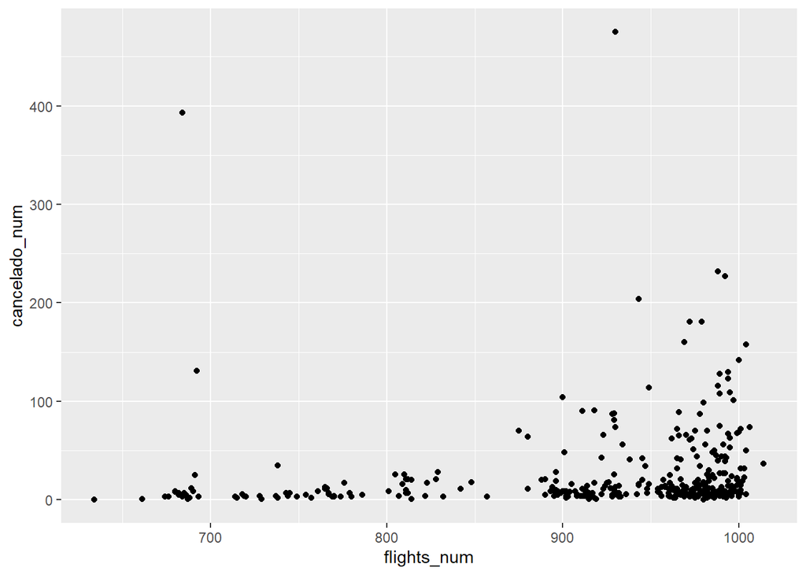

```r
ggplot(cancelado_por_dia) +
  geom_point(aes(x = flights_num, y = cancelado_num))
```

## 17. Investiga si la proporción de vuelos cancelados está relacionada con el retraso promedio por día en los vuelos.

```r
cancelados_y_retrasos <-
  fly %>%
  mutate(cancelado = (is.na(arr_delay) | is.na(dep_delay))) %>%
  group_by(year, month, day) %>%
  summarise(
    prop_cancelado = mean(cancelado),
    media_dep_delay = mean(dep_delay, na.rm = TRUE),
    media_arr_delay = mean(arr_delay, na.rm = TRUE)
  ) %>%
  ungroup()
```

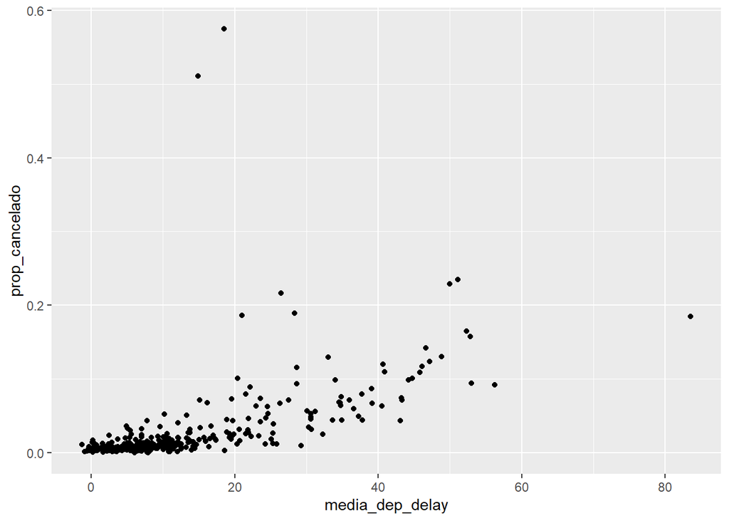

```r
ggplot(cancelados_y_retrasos) +
  geom_point(aes(x = media_dep_delay, y = prop_cancelado))
```

Hay una fuerte relacion entre el retraso en las salidas y en las llegadas con la proporcion de vuelos cancelados.

## 18. Investiga si la proporción de vuelos cancelados está relacionada con el retraso promedio por aeropuerto en los vuelos.

```r
cancelados_y_retrasos_A <-
  fly %>%
  mutate(cancelado = (is.na(arr_delay) | is.na(dep_delay))) %>%
  group_by(origin, dest) %>%
  summarise(
    prop_cancelado = mean(cancelado),
    media_dep_delay = mean(dep_delay, na.rm = TRUE),
    media_arr_delay = mean(arr_delay, na.rm = TRUE)
  ) %>%
  ungroup()
```

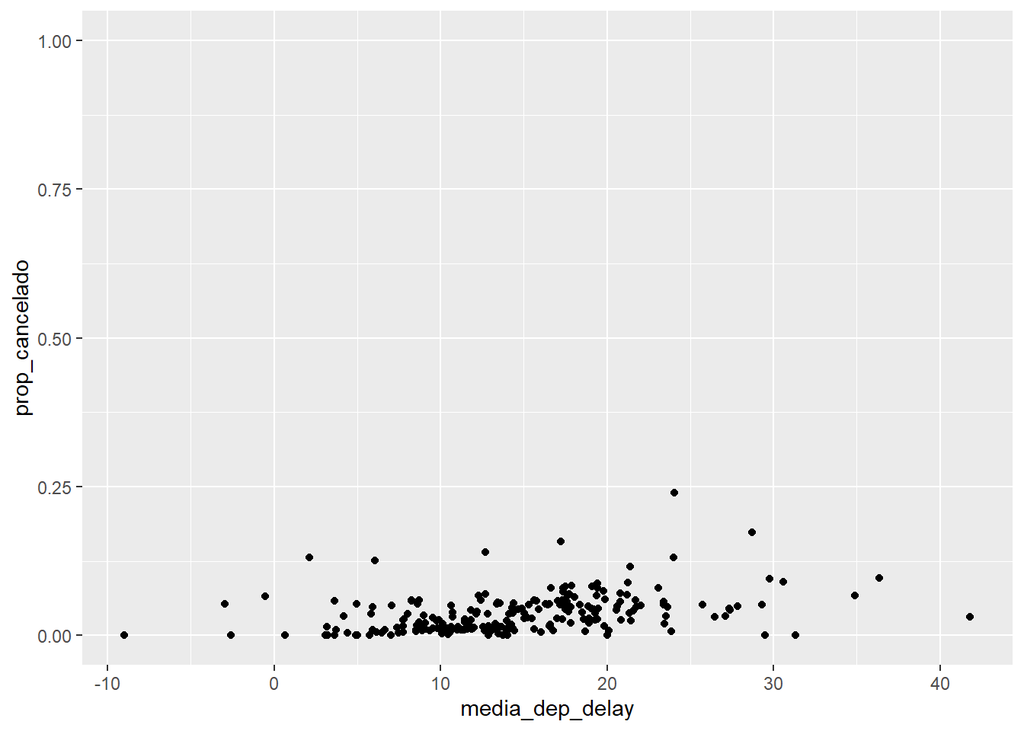

```r
ggplot(cancelados_y_retrasos_A) +
  geom_point(aes(x = media_dep_delay, y = prop_cancelado))
```

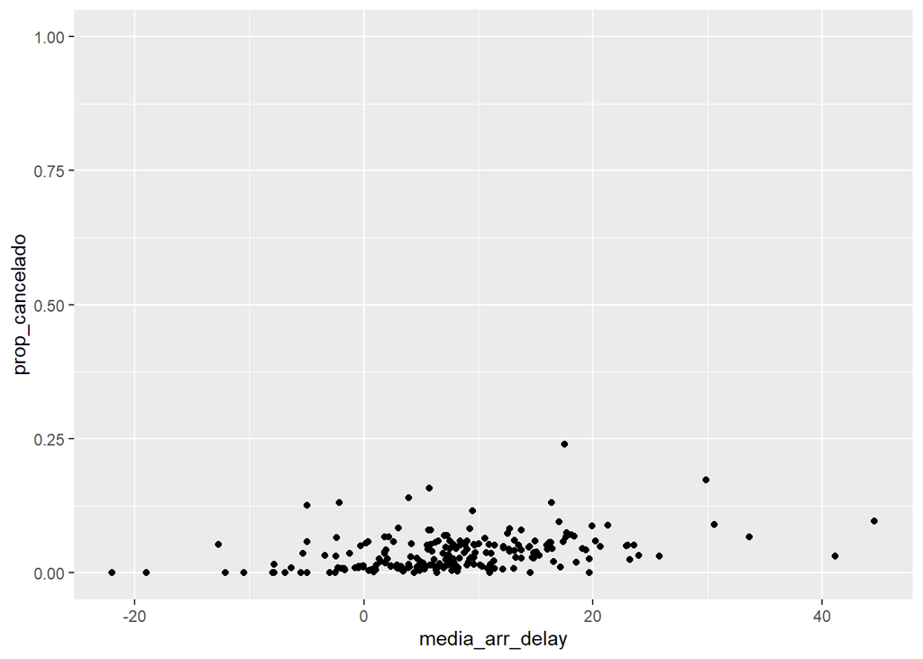

```r
ggplot(cancelados_y_retrasos_A) +
  geom_point(aes(x = media_arr_delay, y = prop_cancelado))
```

Se puede observar que existe relación, ya que a mayor retraso promedio por aeropuerto en la salida o llegada, mayor proporcion de vuelos cancelados.

## 19. ¿Qué compañía aérea sufre los peores retrasos?

```r
fly %>%
  group_by(carrier) %>%
  summarise(arr_delay = mean(arr_delay, na.rm = TRUE)) %>%
  arrange(desc(arr_delay))
```

```
## # A tibble: 16 x 2
##    carrier arr_delay
##    <chr>       <dbl>
##  1 F9         21.9
##  2 FL         20.1
##  3 EV         15.8
##  4 YV         15.6
##  5 OO         11.9
##  6 MQ         10.8
##  7 WN          9.65
##  8 B6          9.46
##  9 9E          7.38
## 10 UA          3.56
## 11 US          2.13
## 12 VX          1.76
## 13 DL          1.64
## 14 AA          0.364
## 15 HA         -6.92
## 16 AS         -9.93
```

```r
fly %>%
  group_by(carrier) %>%
  summarise(dep_delay = mean(dep_delay, na.rm = TRUE)) %>%
  arrange(desc(dep_delay))
```

```
## # A tibble: 16 x 2
##    carrier dep_delay
##    <chr>       <dbl>
##  1 F9          20.2
##  2 EV          20.0
##  3 YV          19.0
##  4 FL          18.7
##  5 WN          17.7
##  6 9E          16.7
##  7 B6          13.0
##  8 VX          12.9
##  9 OO          12.6
## 10 UA          12.1
## 11 MQ          10.6
## 12 DL           9.26
## 13 AA           8.59
## 14 AS           5.80
## 15 HA           4.90
## 16 US           3.78
```

La peor compañia tanto en retrasos en la salida como en la llegada es F9.

## 20. Queremos saber qué hora del día nos conviene volar si queremos evitar los retrasos en la salida.

```r
fly %>%
  group_by(hour) %>%
  summarise(dep_delay = mean(dep_delay, na.rm = TRUE)) %>%
  arrange(dep_delay)
```

```
## # A tibble: 20 x 2
##     hour dep_delay
##    <dbl>     <dbl>
##  1     5     0.688
##  2     6     1.64
##  3     7     1.91
##  4     8     4.13
##  5     9     4.58
##  6    10     6.50
##  7    11     7.19
##  8    12     8.61
##  9    13    11.4
## 10    14    13.8
## 11    23    14.0
## 12    15    16.9
## 13    16    18.8
## 14    22    18.8
## 15    17    21.1
## 16    18    21.1
## 17    21    24.2
## 18    20    24.3
## 19    19    24.8
## 20     1   NaN
```

La mejor hora del dia para volar si queremos evitar los retrasos en la salida son las 5 de la mañana

## 21. Queremos saber qué día de la semana nos conviene volar si queremos evitar los retrasos en la salida.

```r
make_datetime_100 <- function(year, month, day, time)
{
  make_datetime(year, month, day, time %/% 100, time %% 100)
}

flights_dt <- fly %>%
  filter(!is.na(dep_time), !is.na(arr_time)) %>%
  mutate( dep_time = make_datetime_100(year, month, day, dep_time),
          arr_time = make_datetime_100(year, month, day, arr_time),
          sched_dep_time = make_datetime_100(year, month, day, sched_dep_time),
          sched_arr_time = make_datetime_100(year, month, day, sched_arr_time) ) %>%
  select(origin, dest, ends_with("delay"), ends_with("time"))

flights_dt2<- flights_dt %>%
  mutate(dow = wday(sched_dep_time)) %>%
  group_by(dow) %>%
  summarise(
    dep_delay = mean(dep_delay),
    arr_delay = mean(arr_delay, na.rm = TRUE)
  ) %>%
  print(n = Inf)
```

```
## # A tibble: 7 x 3
##     dow dep_delay arr_delay
##   <dbl>     <dbl>     <dbl>
## 1     1     11.5       4.82
## 2     2     14.7       9.65
## 3     3     10.6       5.39
## 4     4     11.7       7.05
## 5     5     16.1      11.7
## 6     6     14.7       9.07
## 7     7      7.62     -1.45
```

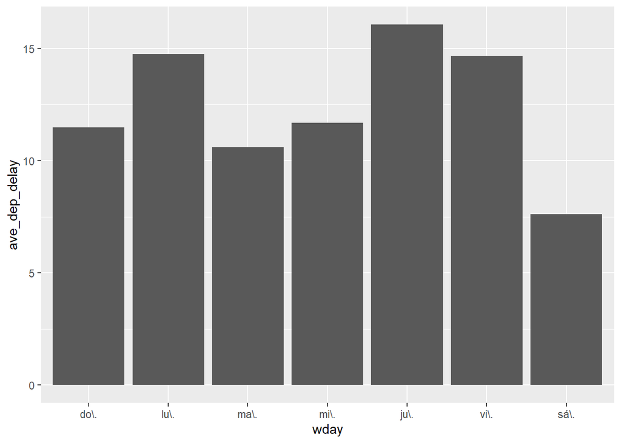

```r
flights_dt %>%
  mutate(wday = wday(dep_time, label = TRUE)) %>% #porque de dep_time
  group_by(wday) %>%
  summarize(ave_dep_delay = mean(dep_delay, na.rm = TRUE)) %>%
  ggplot(aes(x = wday, y = ave_dep_delay)) +
  geom_bar(stat = "identity")
```

Como se ve en la grafica, el mejor dia para volar si quieres evitar retrasos en la salida es el sabado.

## 22. Para cada destino, calcula el total de minutos de retraso acumulado.

```r
retraso_acum<- fly %>%
  filter(arr_delay > 0) %>%
  group_by(dest) %>%
  summarise(total_delay= sum(arr_delay))%>%
  arrange(total_delay)

retraso_acum
```

```
## # A tibble: 103 x 2
##    dest  total_delay
##    <chr>       <dbl>
##  1 PSP            36
##  2 ANC            62
##  3 HDN           119
##  4 SBN           125
##  5 MTJ           170
##  6 EYW           194
##  7 BZN           491
##  8 JAC           619
##  9 CHO           947
## 10 MYR          1016
## # ... with 93 more rows
```

## 23. Para cada uno de ellos, calcula la proporción del total de retraso para dicho destino.

```r
suma_retrasos <-sum(retraso_acum$total_delay)
proporcion_retrasos <- retraso_acum$total_delay / suma_retrasos

retrasos_prop <- data.frame(retraso_acum$dest , proporcion_retrasos)

retrasos_prop
```

```
##     retraso_acum.dest proporcion_retrasos
## 1                 PSP        6.709266e-06
## 2                 ANC        1.155485e-05
## 3                 HDN        2.217785e-05
## 4                 SBN        2.329606e-05
## 5                 MTJ        3.168264e-05
## 6                 EYW        3.615549e-05
## 7                 BZN        9.150693e-05
## 8                 JAC        1.153621e-04
## 9                 CHO        1.764910e-04
## 10                MYR        1.893504e-04
## 11                ILM        3.561502e-04
## 12                MVY        4.021832e-04
## 13                TVC        4.349840e-04
## 14                ACK        5.542599e-04
```

[output cut: 89 more lines]

## 24. Es hora de aplicar todo lo que hemos aprendido para visualizar mejor los tiempos de salida para vuelos cancelados vs los no cancelados. Recuerda bien qué tipo de dato tenemos en cada caso. ¿Qué deduces acerca de los retrasos según la hora del día a la que está programada el vuelo de salida?

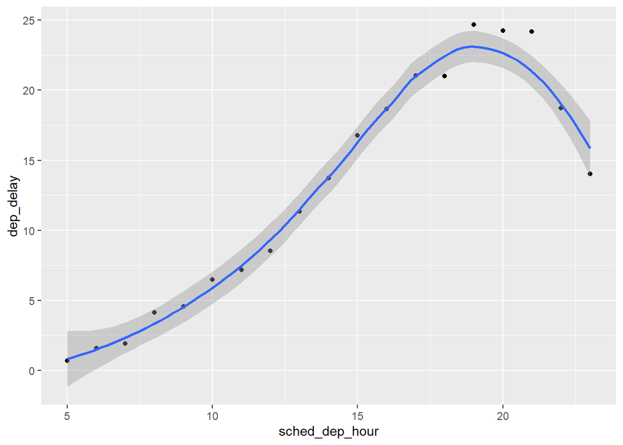

```r
flights_dt %>%
  mutate(sched_dep_hour = hour(sched_dep_time)) %>%
  group_by(sched_dep_hour) %>%
  summarise(dep_delay = mean(dep_delay)) %>%
  ggplot(aes(y = dep_delay, x = sched_dep_hour)) +
  geom_point() +
  geom_smooth()
```

## 25. Subir la carpeta a github y facilitar la url.

https://github.com/JavierML1/TRABAJO_PERSONAL_JavierML.git